# Technical Analysis

2021-04-09

## 1.Background

Many investors analyze stocks based on their fundamentals such as their revenue, valuation, or industry trends but fundamental factors aren’t always reflected in the market price.

**Technical analysis** using charts help to identify trading signals and price patterns, and provides as a window into market psychology to identify opportunities to profit.

Project Group Scope : provides various tools for a *beginner* investor,to analyse stocks past performance and forecasting with 3 parts:  
1)Forecasting ( leveraging **ModelTime** package)  
2)Visualisations for Stock Performance ( leveraging **TidyQuant** Package)  
3)Extensive Time Series analysis ( leveraging **TimeTK**)

** I will be covering part 2).**

## 2. Objective/Layout of this assignment

This assignment explores the features of TidyQuant to experiment what is best of the user, and also to identify any gaps that an eventually Shiny App implementation can adderss to improve the user’s experience.

After some research,the following 3 charts provide the most information for the beginner trader to study a **single stock**:

- 1. Price Movement - Candlesticks Chart
  - This chart reflect the impact of investor sentiment on security prices and are used by technical analysts to determine when to enter and exit trades.
- 2. Stock Price and Trading Volume - Line Charts/Bart Charts
  - This chart provide the the volumes have been in the past and what they are currently before making a decision.
- 3. Moving averages (15-day, 50-day and 200-day) on a particular stock price movement-
  - This chart provides information about the moving average. For Liquid/Volatile stocks may benefit from shorter (eg.15-day) moving average analysis where as illiquid stocks my be examined with 50-day moving average.

After some research, the typical four charts that is useful for a trader to analysis of **group of stocks** or **portfolio** :

- 1)Closing prices
- 2)Moving Average
- 3)Bollinger Bands
- 4)Annual Returns

## 3. Literature Review - Why TidyQuant (Tidy Quantitative Financial Analysis)

[figure not shown]

```r
# Loads tidyquant, lubridate, xts, quantmod, TTR, and PerformanceAnalytics

packages <- c('tidyverse','tidyquant','lubridate','xts','quantmod','TTR','PerformanceAnalytics')

for (p in packages){
  if (!require(p,character.only=T)){
    install.packages(p)
  }
  library(p, character.only=T)
}
```

[output not shown]

TidyQuant addresses a few gaps that in the existing quantitative analysis functions (QAF).

- GAP-1
  - Existing Quantitative analysis functions (QAF) -such as xts, zoo, quantmod, TTR, and PerformanceAnalytics work with time-series objects. These objects do not work well with the data frames or the tidyverse workflow.
- SOLUTION- 1 +TidyQuant addresses this by providing a wrapper to enabling seamless usage within the tidyverse workflow.
- GAP-2: Existing QAF functions for Stock Analysis do not provide any easy to use functions to load stock information and stock indices.
  - SOLUTION-2 : TidyQuant addresses this by implementing the following functions :Get a Stock Index, tq_index(), or a Stock Exchange, tq_exchange(): Returns the stock symbols and various attributes for every stock in an index or exchange. Eighteen indexes and three exchanges are available. To get Quantitative Data, tq_get()is implemented to provide a one-stop shop to get data from various web-sources.
- GAP-3 : PerformanceAnalytics package consolidates functions to compute many of the most widely used performance metrics.
  - SOLUTION -3 : Tidyquant integrates this functionality so it can be used at scale using the split, apply, combine framework within the tidyverse. Two primary functions integrate the performance analysis functionality:
    - tq_performance implements the performance analysis functions in a tidy way, enabling scaling analysis using the split, apply, combine framework
    - tq_portfolio provides a useful tool set for aggregating a group of individual asset returns into one or many portfolios.

### 3.1 TidyQuant - Charting

The tidyquant package leverages ggplot2 - and has three primary geometry (geom) categories and one coordinate manipulation (coord) category that i will explore:

- *Chart Types*: Two chart type visualizations are available using geom_barchart and geom_candlestick.
- *Moving Averages*: Seven moving average visualizations are available using geom_ma.
- *Bollinger Bands*: Bollinger bands can be visualized using geom_bbands. The BBand moving average can be one of the seven available in Moving Averages.
- *Zooming in on Date Ranges*:
  - Two coord functions are available (coord_x_date and coord_x_datetime), which prevent data loss when zooming in on specific regions of a chart. This is important when using the moving average and Bollinger band geoms.

### 3.2 TidyQuant - Portfolio Analysis

The *Performance Analytics* package in TidyQuant consolidates functions to compute the most widely used stock performance metrics. Tidquant integrates this functionality so it can be used at scale using the split, apply, combine framework within the tidyverse.

- Two primary functions integrate the performance analysis functionality:
  - *tq_performance* - implements the performance analysis functions in a tidy way, enabling scaling analysis using the split, apply, combine framework.
  - *tq_portfolio* - provides a useful tool set for aggregating a group of individual asset returns into one or many portfolios.

## 4. Loading and Preping Data : Single Stock and Multiple Stock analysis

Tidyquant provides a function tq_get for directly loading data. For the purpose of this assignment i use this funciton to get the data for APPLE, AMAZON, FACEBOOK< GOOGLE, NETFLIX. To preapre for a multi-stock analysis evaluation, i also built combined data set.

```r
AAPL <- tq_get("AAPL", get = "stock.prices", from = "2011-01-01", to = "2021-03-31")
AMZN <- tq_get("AMZN", get = "stock.prices", from = "2011-01-01", to = "2021-03-31")
GOOG <- tq_get("GOOG",get = "stock.prices", from = "2011-01-01", to = "2021-03-31")
NFLX <- tq_get("NFLX",get = "stock.prices", from = "2011-01-01", to = "2021-03-31")
FB <- tq_get("FB",get = "stock.prices", from = "2011-01-01", to = "2021-03-31")
```

```r
FAANG<- rbind(FB,AAPL,AMZN,NFLX,GOOG)
```

Setup the End Data for review as last day in March of 2021

```r
end <- as_date("2021-03-31")
```

## 5.Testing and Prototyping - Single Stock Analysis ( Using APPLE stock)

### 5.1 Candlestick Chart

#### 5.1.1 Candlestick Chart- Complete Period

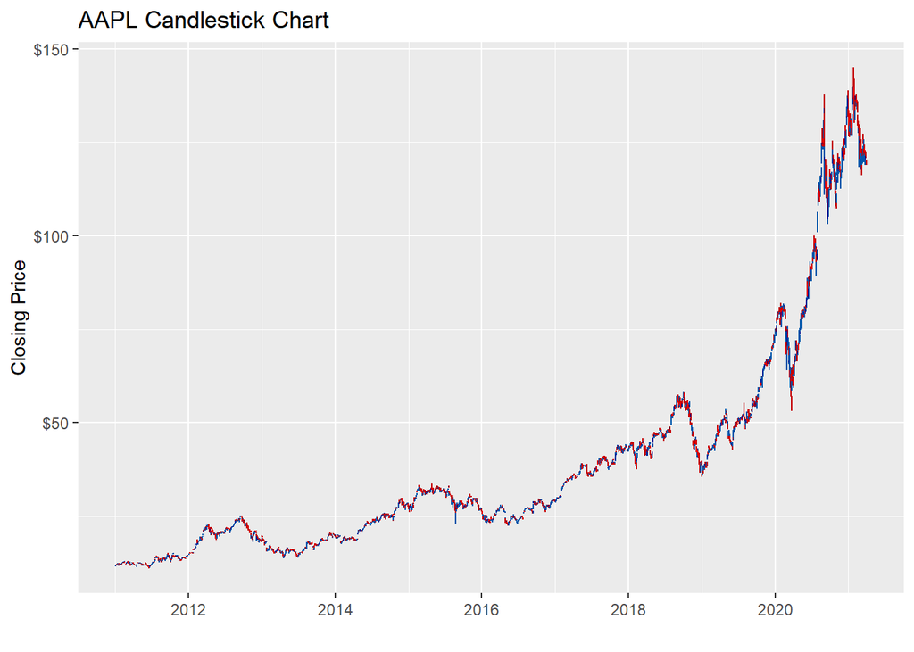

```r
AAPL %>%
    ggplot(aes(x = date, y = close)) +
    geom_candlestick(aes(open = open, high = high, low = low, close = close)) +
    labs(title = "AAPL Candlestick Chart", y = "Closing Price", x = "") +
    scale_color_tq(theme = "dark") +
    scale_y_continuous(labels = scales::dollar)
```

*KEY LEARNING* : A candlestick chart for a long period eg. more than 5 years is not really meaningful. THe user will need to able to zoom into the prefered periods eg. 6 weeks or less.

#### 5.1.2 Candlestick Chart- Zooming into a 6 week window.

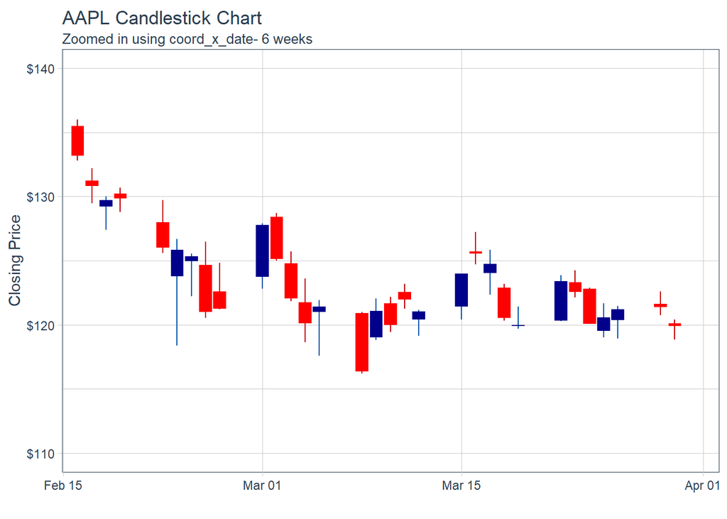

```r
AAPL %>%
    ggplot(aes(x = date, y = close)) +
    geom_candlestick(aes(open = open, high = high, low = low, close = close)) +
    labs(title = "AAPL Candlestick Chart",
         subtitle = "Zoomed in using coord_x_date- 6 weeks",
         y = "Closing Price", x = "") +
    coord_x_date(xlim = c(end - weeks(6), end),
                 ylim = c(110, 140)) +
    theme_tq() +
    scale_color_tq(theme = "dark") +
    scale_y_continuous(labels = scales::dollar)
```

#### 5.1.3 Candlestick Chart- Zooming into 1 week

[figure not shown]

```r
AAPL %>%
    ggplot(aes(x = date, y = close)) +
    geom_candlestick(aes(open = open, high = high, low = low, close = close)) +
    labs(title = "AAPL Candlestick Chart",
         subtitle = "Zoomed in using coord_x_date - 14 days",
         y = "Closing Price", x = "") +
    coord_x_date(xlim = c(end - weeks(1), end),
                 ylim = c(115, 130)) +
    theme_tq() +
    scale_color_tq(theme = "dark") +
    scale_y_continuous(labels = scales::dollar)
```

#### 5.1.4 Candlestick Chart- Using different colours for the candlesticks.

The colors can be modified using colour_up and colour_down, which control the line color, and fill_up and fill_down, which control the rectangle fills.Using RED and GREEN - makes it very clear for the user.. which is the ‘danger’ candlestick.

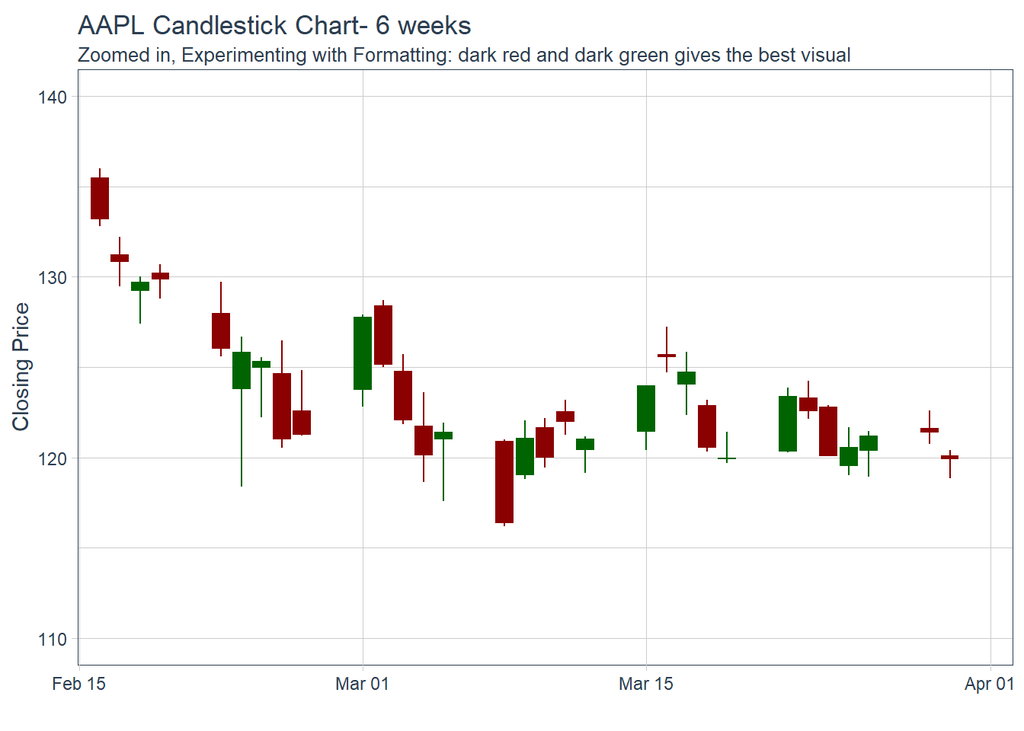

```r
AAPL %>%
    ggplot(aes(x = date, y = close)) +
    geom_candlestick(aes(open = open, high = high, low = low, close = close),
                        colour_up = "darkgreen", colour_down = "darkred",
                        fill_up  = "darkgreen", fill_down  = "darkred") +
    labs(title = "AAPL Candlestick Chart- 6 weeks ",
         subtitle = "Zoomed in, Experimenting with Formatting: dark red and dark green gives the best visual",
         y = "Closing Price", x = "") +
    coord_x_date(xlim = c(end - weeks(6), end),
                 ylim = c(110, 140)) +
    theme_tq()
```

*KEY LEARNING* : Red and Green is a good colour palette to immediately show up the days where the closing price was lower then the opening price ( Red )- makes the candle chart quickly readable.

#### 5.1.5 Price Bar Chart- alternative to candlestick

Price Bar Chart - Each bar typically shows open, high, low, and closing (OHLC) prices. Bar charts are very similar to candlestick charts. The two chart types show the same information but in different ways. A bar chart is composed of a vertical line with small horizontal lines on the left and right that show the open and close. Candlesticks also have a vertical line showing the high and low of the period (called a shadow or wick), but the difference between the open and close is represented by a thicker portion called a real body. The body is shaded in or colored red if the close is below the open. The body is white or green if the close is above the open. While the information is the same, the visual look of the two chart types is different.

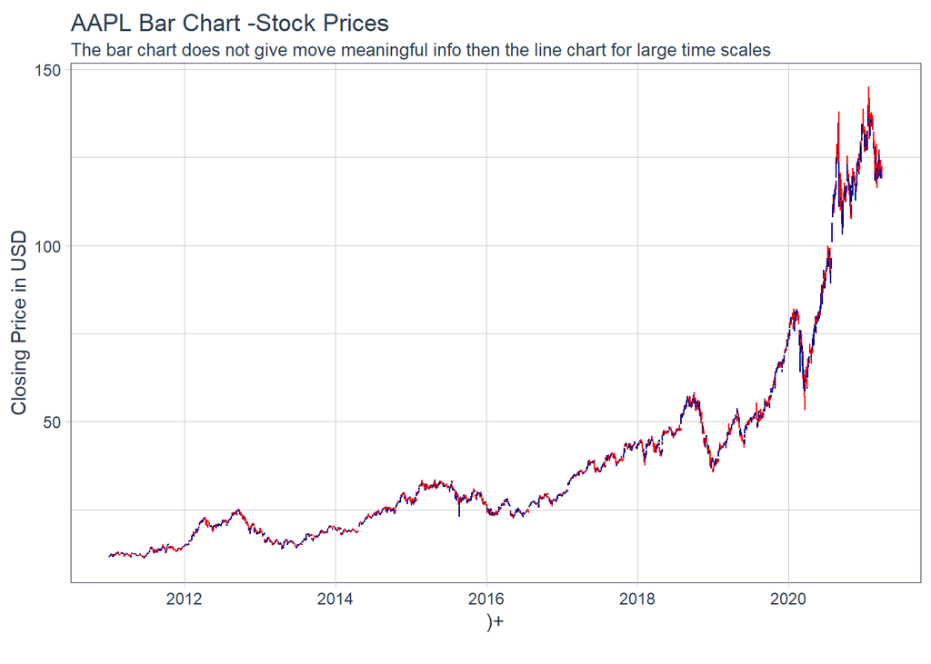

```r
AAPL %>%
    ggplot(aes(x = date, y = close)) +
    geom_barchart(aes(open = open, high = high, low = low, close = close)) +
    labs(title = "AAPL Bar Chart -Stock Prices",
         subtitle = "The bar chart does not give move meaningful info then the line chart for large time scales",
         y = "Closing Price in USD", x = ")+
         ")+
    theme_tq()
```

*KEY LEARNING* : The bar chart does not give move meaningful info then the line chart for large time scales

#### 5.1.6 Price BarChart- for 4 weeks - zoomed in

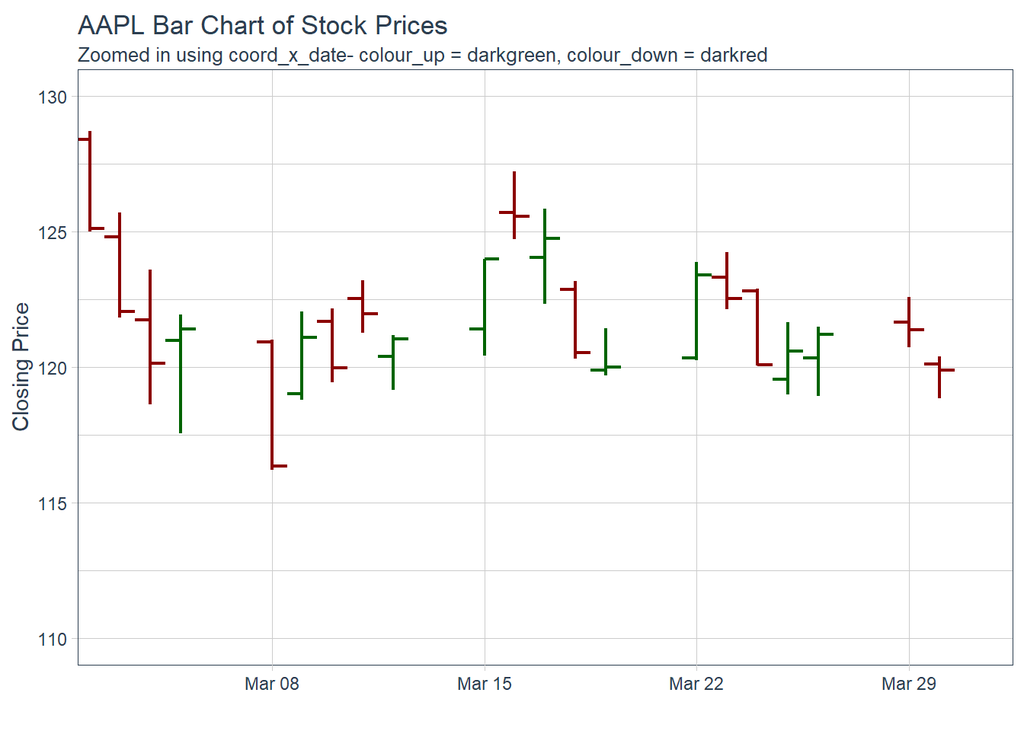

```r
AAPL %>%
    ggplot(aes(x = date, y = close)) +
    geom_barchart(aes(open = open, high = high, low = low, close = close),
                  colour_up = "darkgreen", colour_down = "darkred", size = 0.8) +
    labs(title = "AAPL Bar Chart of Stock Prices",
         subtitle = "Zoomed in using coord_x_date- colour_up = darkgreen, colour_down = darkred",
         y = "Closing Price", x = "") +
    coord_x_date(xlim = c(end - weeks(4), end),
                 ylim = c(110, 130)) +
     theme_tq()
```

*Key Learning* :Candle Charts far easier to interpret than Pricebarcharts and much easier to read.

### 5.2 Stock Price/TradingVolume/Returns

Exploring the varies ways to visualize Price/TradingVolume/Returns/Moving Averages.

#### 5.2.1 Price Line Chart- for the full period

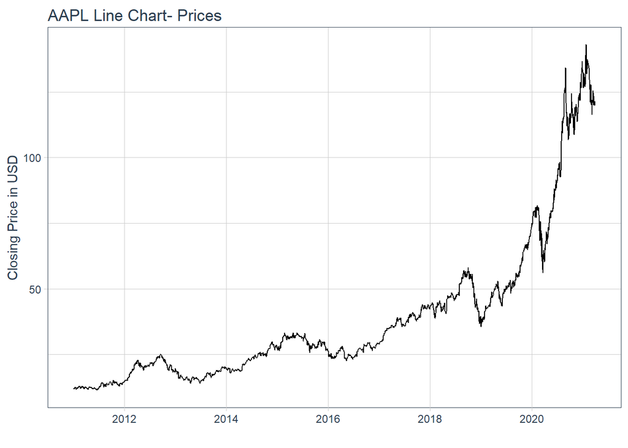

```r
AAPL %>%
    ggplot(aes(x = date, y = close)) +
    geom_line() +
    labs(title = "AAPL Line Chart- Prices", y = "Closing Price in USD", x = "") +
    theme_tq()
```

#### 5.2.2 Stock Volume Chart

We can use the **geom_segment()** function to chart daily volume, which uses xy points for the beginning and end of the line. Using the aesthetic color argument, we color based on the value of volume to make these data stick out.

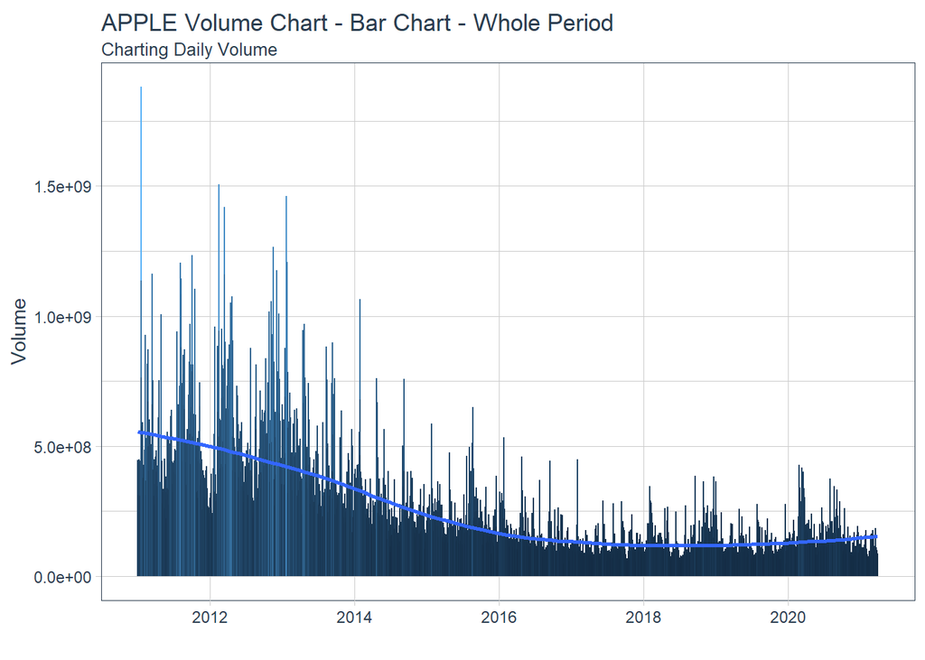

```r
AAPL %>%
    ggplot(aes(x = date, y = volume)) +
    geom_segment(aes(xend = date, yend = 0, color = volume)) +
    geom_smooth(method = "loess", se = FALSE) +
    labs(title = "APPLE Volume Chart - Bar Chart - Whole Period",
         subtitle = "Charting Daily Volume",
         y = "Volume", x = "") +
    theme_tq() +
    theme(legend.position = "none")
```

And, we can zoom in on a specific region. Using scale_color_gradient we can quickly visualize the high and low points, and using geom_smooth we can see the trend.

[figure not shown]

```r
start <- end - weeks(24)

AAPL %>%
    filter(date >= start - days(20)) %>%
    ggplot(aes(x = date, y = volume)) +
    geom_segment(aes(xend = date, yend = 0, color = volume)) +
    geom_smooth(method = "loess", se = FALSE) +
    labs(title = "APPLE Price Chart - Bar Chart- WHole Period",
         subtitle = "Charting Daily Volume, Zooming In to past 20 days",
         y = "Volume", x = "") +
    coord_x_date(xlim = c(start, end)) +
    scale_color_gradient(low = "red", high = "darkblue") +
    theme_tq() +
    theme(legend.position = "none")
```

#### 5.2.4 Single Stock Returns Chart - Line Chart/Time series.

Showing monthly return for single stock

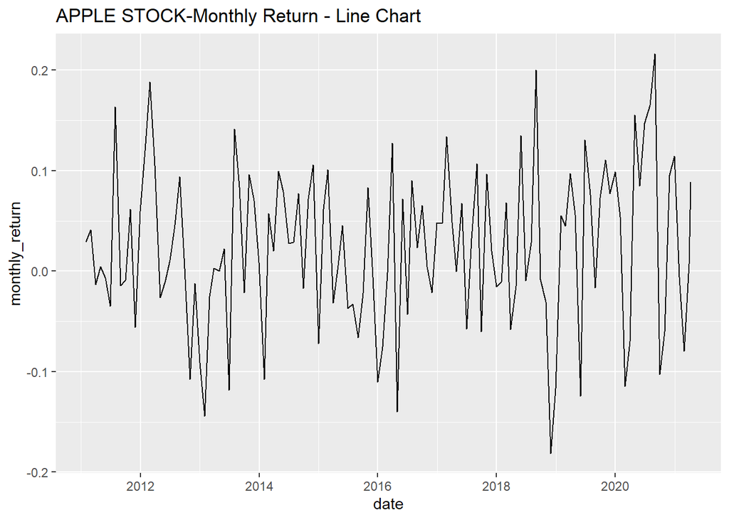

```r
tq_get(c("AAPL"), get="stock.prices") %>%
  tq_transmute(select=adjusted,
               mutate_fun=periodReturn,
               period="monthly",
               col_rename = "monthly_return") %>%
  ggplot(aes(date, monthly_return)) +
  labs(title = "APPLE STOCK-Monthly Return - Line Chart") +
  geom_line()
```

#### 5.2.5 Moving Averages

Visualizing Trends averages is important for time-series analysis of stocks. For example : A simple moving average (SMA) calculates the average of a selected range of prices, usually closing prices, by the number of periods in that range. A simple moving average is a technical indicator that can aid in determining if an asset price will continue or if it will reverse a bull or bear trend.A simple moving average can be enhanced as an exponential moving average (EMA) that is more heavily weighted on recent price action.

Tidyquant includes geoms to enable “rapid prototyping” to quickly visualize signals using moving averages and Bollinger bands.

Within Tidyquant the following moving averages are available:

1)Simple moving averages (SMA) 2)Exponential moving averages (EMA)

.. and more advanced averages : 3)Weighted moving averages (WMA) 4)Double exponential moving averages (DEMA) 5)Zero-lag exponential moving averages (ZLEMA) 6)Volume-weighted moving averages (VWMA) (also known as VWAP) 7)Elastic, volume-weighted moving averages (EVWMA) (also known as MVWAP)

For exploration : We will visualize the SMA, EMA.

##### 5.2.5.1 Charting the 14-day,50-day and 200-day Simple Moving Average

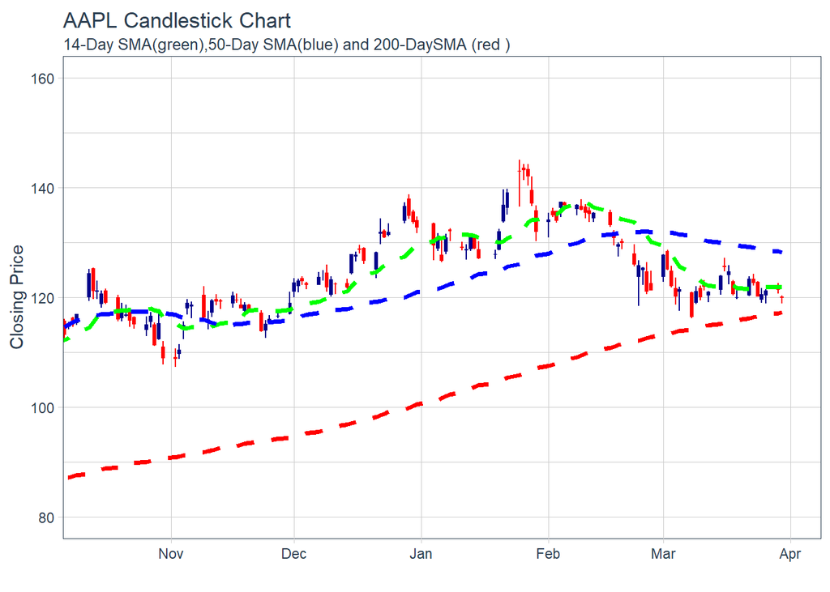

```r
AAPL %>%
    ggplot(aes(x = date, y = close)) +
    geom_candlestick(aes(open = open, high = high, low = low, close = close)) +
    geom_ma(ma_fun = SMA, n = 14, color= 'green', size = 1.25) +
    geom_ma(ma_fun = SMA, n = 50, color= 'blue', size = 1.25) +
    geom_ma(ma_fun = SMA, n = 200, color = "red", size = 1.25) +
    labs(title = "AAPL Candlestick Chart",
         subtitle = "14-Day SMA(green),50-Day SMA(blue) and 200-DaySMA (red )",
         y = "Closing Price", x = "") +
    coord_x_date(xlim = c(end - weeks(24), end),
                 ylim = c(80, 160)) +
    theme_tq()
```

##### 5.2.5.2 Charting Exponential Moving Average (EMA)

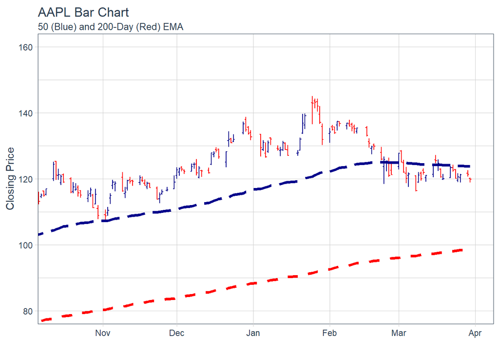

```r
AAPL %>%
    ggplot(aes(x = date, y = close)) +
    geom_barchart(aes(open = open, high = high, low = low, close = close)) +
    geom_ma(ma_fun = EMA, n = 50, wilder = TRUE, linetype = 5, size = 1.25) +
    geom_ma(ma_fun = EMA, n = 200, wilder = TRUE, color = "red", size = 1.25) +
    labs(title = "AAPL Bar Chart",
         subtitle = "50 (Blue) and 200-Day (Red) EMA ",
         y = "Closing Price", x = "") +
    coord_x_date(xlim = c(end - weeks(24), end),
                 ylim = c(80, 160)) +
    theme_tq()
```

##### 5.2.5.3 Charting for Reviewing Stock Volatility - Bolingar Bands

WHy Bollinger Bands - Bollinger Bands are used to visualize volatility by plotting a range around a moving average typically two standard deviations up and down. Because they use a moving average, the geom_bbands function works almost identically to geom_ma. The same seven moving averages are compatible. The main difference is the addition of the standard deviation, sd, argument which is 2 by default, and the high, low and close aesthetics which are required to calculate the bands.

##### 5.2.5.4.1 Applying BBands using a SMA

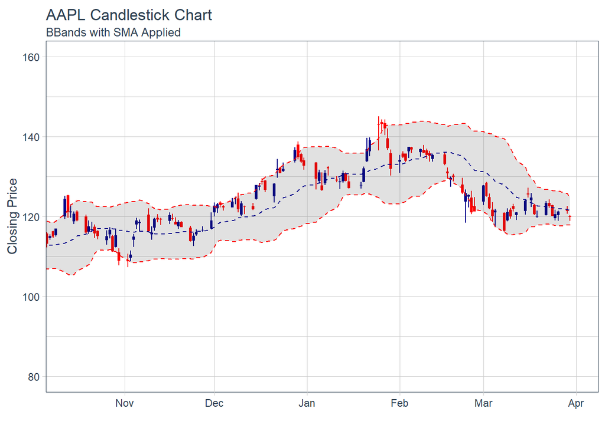

```r
AAPL %>%
    ggplot(aes(x = date, y = close, open = open,
               high = high, low = low, close = close)) +
    geom_candlestick() +
    geom_bbands(ma_fun = SMA, sd = 2, n = 20) +
    labs(title = "AAPL Candlestick Chart",
         subtitle = "BBands with SMA Applied",
         y = "Closing Price", x = "") +
    coord_x_date(xlim = c(end - weeks(24), end),
                 ylim = c(80, 160)) +
    theme_tq()
```

Modifying the appearance of Bollinger Bands

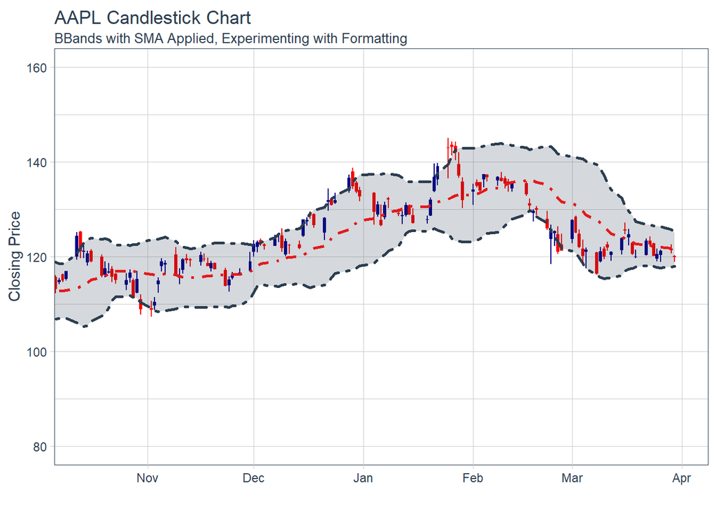

```r
AAPL %>%
    ggplot(aes(x = date, y = close, open = open,
               high = high, low = low, close = close)) +
    geom_candlestick() +
    geom_bbands(ma_fun = SMA, sd = 2, n = 20,
                linetype = 4, size = 1, alpha = 0.2,
                fill        = palette_light()[[1]],
                color_bands = palette_light()[[1]],
                color_ma    = palette_light()[[2]]) +
    labs(title = "AAPL Candlestick Chart",
         subtitle = "BBands with SMA Applied, Experimenting with Formatting",
         y = "Closing Price", x = "") +
    coord_x_date(xlim = c(end - weeks(24), end),
                 ylim = c(80, 160)) +
    theme_tq()
```

## 6. Charting for Multiple Securities

The main fucntion here is to use **facet_wrap** to visualize multiple stocks at the same time. By adding a group aesthetic in the main ggplot() function and combining with a facet_wrap() function at the end of the ggplot workflow, all five “FAANG” stocks can be viewed simultaneously.

### 6.1 Multiple securities -Closing prices

#### 6.1.1 Multiple securities - closing prices - in a Timeseries Line Chart

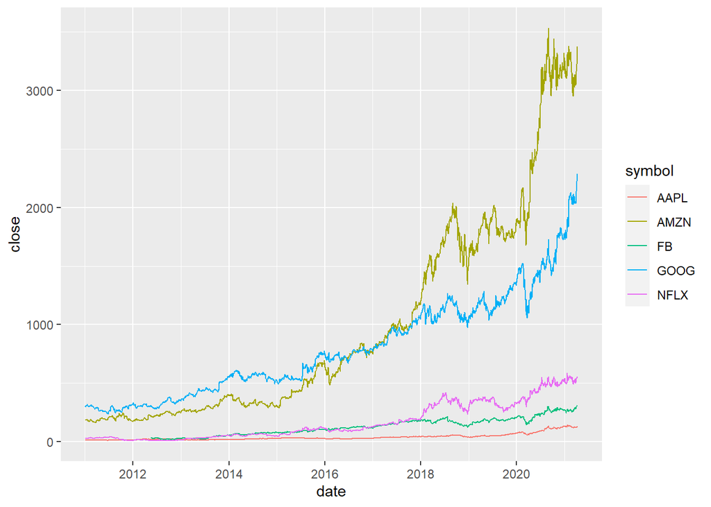

```r
tq_get(c("GOOG","AMZN","FB","AAPL","NFLX"),get="stock.prices") %>%
  ggplot(aes(date, close, color=symbol)) +
  geom_line()
```

#### 6.1.2 Multiple securities - closing prices - in Facet

```r
start <- end - weeks(6)
```

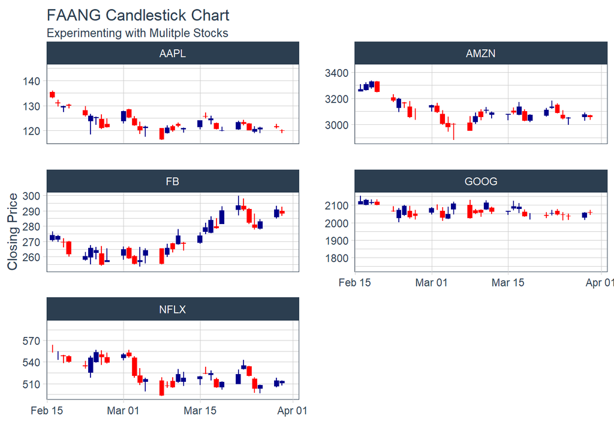

```r
FAANG %>%
    filter(date >= start - days(2 * 15)) %>%
    ggplot(aes(x = date, y = close, group = symbol)) +
    geom_candlestick(aes(open = open, high = high, low = low, close = close)) +
    labs(title = "FAANG Candlestick Chart",
         subtitle = "Experimenting with Mulitple Stocks",
         y = "Closing Price", x = "") +
    coord_x_date(xlim = c(start, end)) +
    facet_wrap(~ symbol, ncol = 2, scale = "free_y") +
    theme_tq()
```